```python
%pylab inline
pylab.rcParams['figure.figsize'] = (16.0, 8.0)
```

# Drawing random numbers in Python

## 1. Drawing using the rectangular distribution

The prerequisite for drawing from a probability distribution is the ability to draw randomly from the rectangular or uniform distribution on $(0,1)$.

For any other distribution, draws can be generated by

1) draw $\xi$ randomly from the uniform distribution

2) evaluate the inverse cumulative distribution function $G^{-1}(x)$ at $\xi$

### Implementation in Python

Uniform numbers in Python are drawn by

```
import numpy as np
    xi = np.random.rand(size)
```

with *size* the number of random draws.

Probability distributions are implemented in *scipy* with inverse cumulative distributions being implemented as **ppf** for the individual probability distributions:

```
import scipy.stats as stats
    # normal distribution
    stats.norm.ppf(q, loc = 0, scale = 1)
    # gamma distribution
    stats.gamma.ppf(q, a, loc = 0, scale = 1)
    # t-distribution
    stats.t.ppf(q, dof, loc = 0, scale = 1)
    # poisson distribution
    stats.poisson.ppf(q, mu, loc = 0)
```

### Exercise 1.1

Using the rectangular distribution, draw 1000 random numbers from

- normal distribution with mean $\mu=0.2$ and standard deviation $\sigma=0.1$
- gamma distribution with shape parameter $a=2.5$ and scale parameter $s=0.2$
- t-distribution with 5 degrees of freedom, located around $3.5$ and with scale $s=0.8$

Plot a histogram for each outcome.

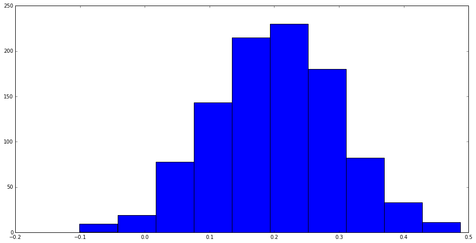

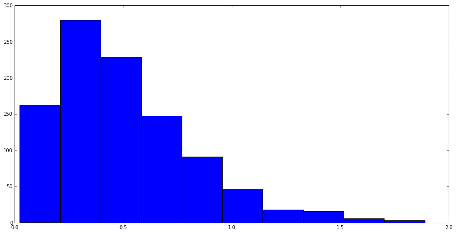

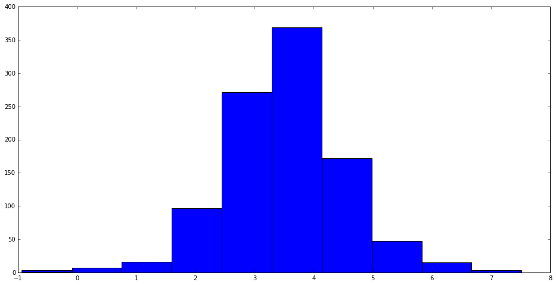

```python
# Solution for Exercise 1.1

from numpy.random import rand    # import function for drawing random numbers
import scipy.stats as stats      # import statistics package

# uniformly distributed values
q = rand(1000)

# normal distribution with mean=0.2 and std=0.1
nxi = stats.norm.ppf(q, loc = 0.2, scale = 0.1)
figure()
hist(nxi);

# gamma distribution with a=2.5, scale=0.2
gxi = stats.gamma.ppf(q, 2.5, scale = 0.2)
figure()
hist(gxi);

# t-distribution with 5 degrees-of-freedom, mean=3.5 and std=0.8
txi = stats.t.ppf(q, 5, loc = 3.5, scale = 0.8)
figure()
hist(txi);
```

## 2. Drawing using the built-in generator functions

The **scipy.stats** package provides over 90 different probability distributions, each with its own random number generating function.

The basic usage is

1) Import the **scipy.stats** package

```
import scipy.stats as stats
```

2) Call the **rvs** function of the sought probalitity distribution with size as keyword argument

```
xi = stats.norm.rvs(size=1000)
    xi = stats.gamma.rvs(a, size=1000)
    xi = stats.t.rvs(dof, size=1000)
```

The optional keyword parameters for each distribution correspond to those of the call for the inverse cumulative distribution function.

### Exercise 1.2

Repeat the random number generation from Exercise 1.1, but now use the built-in **rvs** function for each example.

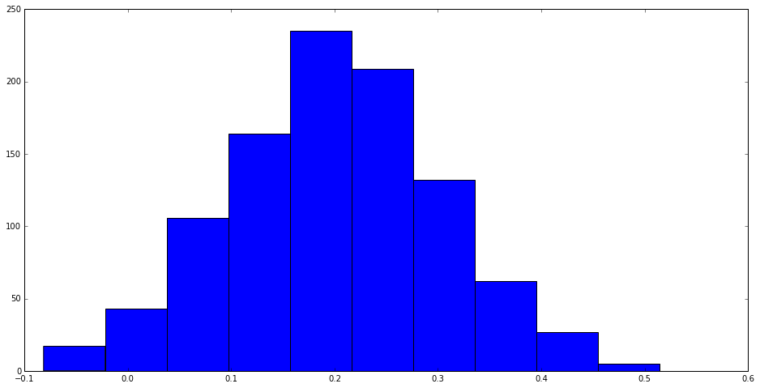

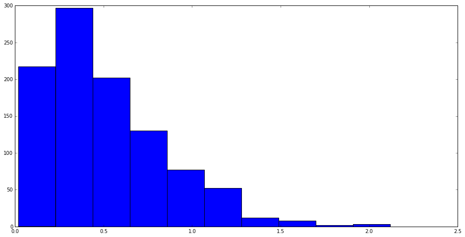

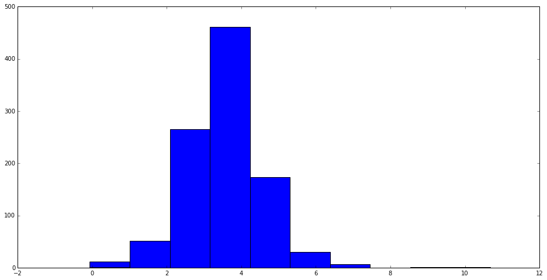

```python
# solution for exercise 1.2

# normal distribution with mean=0.2 and std=0.1
nxi = stats.norm.rvs(loc = 0.2, scale = 0.1, size = 1000)
figure()
hist(nxi);

# gamma distribution with a=2.5, scale=0.2
gxi = stats.gamma.rvs(2.5, scale = 0.2, size = 1000)
figure()
hist(gxi);

# t-distribution with 5 degrees-of-freedom, mean=3.5 and std=0.8
txi = stats.t.rvs(5, loc = 3.5, scale = 0.8, size = 1000)
figure()
hist(txi);
```

### Bonus: Advanced plotting

```python
# import advanced plotting color pallettes
from palettable.colorbrewer.qualitative import Dark2_8
colors = Dark2_8.mpl_colors

# probability distribution as an object
dist = stats.t(5, loc=3.5, scale=0.8)
# random number generator is method of the distribution object
xi = dist.rvs(size = 10000)
```

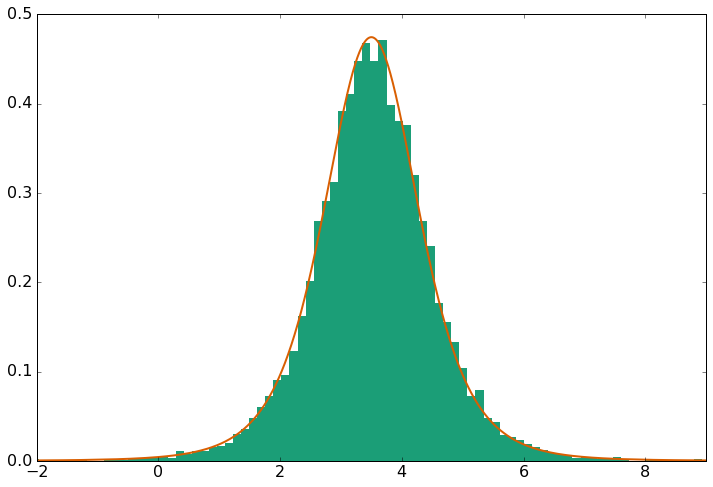

```python
figure(figsize=(12,8))
hist(xi, bins = 100, edgecolor="none", color=colors[0], normed=True);
plot(np.sort(xi), dist.pdf(np.sort(xi)), color=colors[1], linewidth=2)
tick_params(which="major", labelsize=16)
xlim(-2,9);
```